# TFM_PEC3

[figure not shown]

Alex Pardo Ramos

2021-2 · Máster universitario en Ciencia de datos (Data science)

Estudios de Informática, Multimedia y Telecomunicación

# Detección y clasificación de malware

## Trabajo final de máster

### 0. Contexto y carga de librerías

El siguiente código carga los paquetes necesarios para la parte práctica y lee los ficheros de datos que usaremos.

```python
## @inproceedings{bodmas,
##   title = {BODMAS: An Open Dataset for Learning based Temporal Analysis of PE Malware},
##   author = {Yang, Limin and Ciptadi, Arridhana and Laziuk, Ihar and Ahmadzadeh, Ali and Wang, Gang},
##   booktitle = {4th Deep Learning and Security Workshop},
##   year = {2021}
## }

import numpy as np
import pandas as pd
import matplotlib.pyplot as plt
import collections
import timeit

import keras
from keras.models import Sequential, Model
from keras.layers import Dense
from tensorflow.keras.optimizers import Adam, SGD, Adadelta, Adagrad

from sklearn.preprocessing import OneHotEncoder, StandardScaler
from sklearn.model_selection import train_test_split
from sklearn.metrics import confusion_matrix, mean_squared_error, classification_report

##Para leer directamente de Google drive en Google Colab usar:
from google.colab import drive
drive.mount('/content/drive')

datos = np.load("./drive/MyDrive/TFM/bodmas.npz")
datostipos = pd.read_csv("./drive/MyDrive/TFM/bodmas_malware_category.csv")
```

### 1. Exploración

Este trabajo trata de la detección de malware utilizando el Deep Learning. Utilizaremos para ello un dataset abierto como es BODMAS Malware Dataset. En especial, utilizaremos dos archivos que estudiaremos a continuación:

- bodmas.npz

```python
# Files del dataset
datos.files
```

```
['X', 'y']
```

```python
X = datos['X']  # Todos los vectores de caracteristicas
y = datos['y']  # Etiquetas, 0 para benigno, 1 para malicioso

#Shapes
print("X contiene: ", X.shape)
print()
print("y contiene: ", y.shape)
```

```
X contiene:  (134435, 2381)

y contiene:  (134435,)
```

```python
#Muestra variable X
X
```

```
array([[0.05674198, 0.00801749, 0.00776239, ..., 0.        , 0.        ,
        0.        ],
       [0.00706228, 0.00449971, 0.00449817, ..., 0.        , 0.        ,
        0.        ],
       [0.0209748 , 0.00469876, 0.00400208, ..., 0.        , 0.        ,
        0.        ],
       ...,
       [0.1423067 , 0.01637877, 0.01097404, ..., 0.        , 0.        ,
        0.        ],
       [0.14230758, 0.01637877, 0.01097404, ..., 0.        , 0.        ,
        0.        ],
       [0.1423067 , 0.01637877, 0.01097404, ..., 0.        , 0.        ,
        0.        ]], dtype=float32)
```

```python
#Muestra variable y
y
```

```
array([0, 0, 0, ..., 1, 1, 1], dtype=int32)
```

```python
#Conversión variable X a dataframe
data_X = pd.DataFrame(X)
```

```python
#Conversión variable Y a dataframe
data_Y = pd.DataFrame(y)
data_Y = data_Y.set_axis(['y'], axis=1)
```

```python
#Dataset formado por dataframes de X e Y
DatosEDA = pd.concat([data_Y, data_X], axis=1)
DatosEDA
```

|  | y | 0 | 1 | 2 | 3 | 4 | 5 | 6 | 7 | 8 | ... | 2371 | 2372 | 2373 | 2374 | 2375 | 2376 | 2377 | 2378 | 2379 | 2380 |
| --- | --- | --- | --- | --- | --- | --- | --- | --- | --- | --- | --- | --- | --- | --- | --- | --- | --- | --- | --- | --- | --- |
| 0 | 0 | 0.056742 | 0.008017 | 0.007762 | 0.005466 | 0.007762 | 0.004446 | 0.005430 | 0.003061 | 0.009475 | ... | 0.0 | 0.0 | 0.0 | 0.0 | 0.0 | 0.0 | 0.0 | 0.0 | 0.0 | 0.0 |
| 1 | 0 | 0.007062 | 0.004500 | 0.004498 | 0.004318 | 0.004410 | 0.004330 | 0.004265 | 0.004068 | 0.004391 | ... | 0.0 | 0.0 | 0.0 | 0.0 | 120.0 | 16564.0 | 0.0 | 0.0 | 0.0 | 0.0 |
| 2 | 0 | 0.020975 | 0.004699 | 0.004002 | 0.004419 | 0.004214 | 0.003865 | 0.003973 | 0.004297 | 0.003921 | ... | 0.0 | 0.0 | 0.0 | 0.0 | 0.0 | 0.0 | 0.0 | 0.0 | 0.0 | 0.0 |
| 3 | 0 | 0.006482 | 0.003821 | 0.003788 | 0.003866 | 0.003734 | 0.003784 | 0.003884 | 0.003937 | 0.003805 | ... | 0.0 | 0.0 | 0.0 | 0.0 | 140.0 | 16384.0 | 0.0 | 0.0 | 0.0 | 0.0 |
| 4 | 0 | 0.022135 | 0.003972 | 0.003834 | 0.003869 | 0.003759 | 0.003765 | 0.003777 | 0.003863 | 0.003773 | ... | 0.0 | 0.0 | 0.0 | 0.0 | 0.0 | 0.0 | 0.0 | 0.0 | 0.0 | 0.0 |
| ... | ... | ... | ... | ... | ... | ... | ... | ... | ... | ... | ... | ... | ... | ... | ... | ... | ... | ... | ... | ... | ... |
| 134430 | 1 | 0.065420 | 0.005993 | 0.005216 | 0.005492 | 0.005747 | 0.004183 | 0.005373 | 0.004388 | 0.005619 | ... | 72.0 | 1160180.0 | 0.0 | 0.0 | 0.0 | 0.0 | 0.0 | 0.0 | 0.0 | 0.0 |
| 134431 | 1 | 0.065421 | 0.005993 | 0.005216 | 0.005492 | 0.005747 | 0.004183 | 0.005373 | 0.004388 | 0.005617 | ... | 72.0 | 1160180.0 | 0.0 | 0.0 | 0.0 | 0.0 | 0.0 | 0.0 | 0.0 | 0.0 |
| 134432 | 1 | 0.142307 | 0.016379 | 0.010974 | 0.005991 | 0.009369 | 0.005670 | 0.003335 | 0.003099 | 0.009761 | ... | 64.0 | 674640.0 | 0.0 | 0.0 | 2180.0 | 585728.0 | 0.0 | 0.0 | 0.0 | 0.0 |
| 134433 | 1 | 0.142308 | 0.016379 | 0.010974 | 0.005991 | 0.009369 | 0.005670 | 0.003335 | 0.003099 | 0.009761 | ... | 64.0 | 674640.0 | 0.0 | 0.0 | 2180.0 | 585728.0 | 0.0 | 0.0 | 0.0 | 0.0 |
| 134434 | 1 | 0.142307 | 0.016379 | 0.010974 | 0.005991 | 0.009369 | 0.005670 | 0.003335 | 0.003099 | 0.009761 | ... | 64.0 | 674640.0 | 0.0 | 0.0 | 2180.0 | 585728.0 | 0.0 | 0.0 | 0.0 | 0.0 |

134435 rows × 2382 columns

```python
#Información del dataset
DatosEDA.info()
```

```
<class 'pandas.core.frame.DataFrame'>
RangeIndex: 134435 entries, 0 to 134434
Columns: 2382 entries, y to 2380
dtypes: float32(2381), int32(1)
memory usage: 1.2 GB
```

```python
#Descripción del dataset
DatosEDA.describe()
```

|  | y | 0 | 1 | 2 | 3 | 4 | 5 | 6 | 7 | 8 | ... | 2371 | 2372 | 2373 | 2374 | 2375 | 2376 | 2377 | 2378 | 2379 | 2380 |
| --- | --- | --- | --- | --- | --- | --- | --- | --- | --- | --- | --- | --- | --- | --- | --- | --- | --- | --- | --- | --- | --- |
| count | 134435.000000 | 134435.000000 | 1.344350e+05 | 1.344350e+05 | 134435.000000 | 134435.000000 | 134435.000000 | 134435.000000 | 134435.000000 | 134435.000000 | ... | 1.344350e+05 | 1.344350e+05 | 1.344350e+05 | 1.344350e+05 | 1.344350e+05 | 1.344350e+05 | 1.344350e+05 | 1.344350e+05 | 1.344350e+05 | 1.344350e+05 |
| mean | 0.426176 | 0.172648 | 1.010044e-02 | 6.500139e-03 | 0.005235 | 0.006897 | 0.004137 | 0.004883 | 0.003462 | 0.005583 | ... | 9.626628e+05 | 8.739114e+05 | 5.165675e+05 | 8.146495e+05 | 7.878387e+05 | 1.007429e+06 | 3.951208e+05 | 6.478318e+05 | 1.250010e+07 | 4.992678e+05 |
| std | 0.494522 | 0.190493 | 1.705093e-02 | 6.990193e-03 | 0.006139 | 0.008296 | 0.004132 | 0.005712 | 0.003811 | 0.003947 | ... | 5.105621e+07 | 3.963689e+07 | 3.834679e+07 | 4.814020e+07 | 5.776622e+07 | 4.259667e+07 | 3.066197e+07 | 3.781882e+07 | 1.493006e+08 | 3.673313e+07 |
| min | 0.000000 | 0.000127 | 4.840046e-07 | 2.765741e-07 | 0.000000 | 0.000000 | 0.000000 | 0.000000 | 0.000000 | 0.000000 | ... | 0.000000e+00 | 0.000000e+00 | 0.000000e+00 | 0.000000e+00 | 0.000000e+00 | 0.000000e+00 | 0.000000e+00 | 0.000000e+00 | 0.000000e+00 | 0.000000e+00 |
| 25% | 0.000000 | 0.018336 | 3.932182e-03 | 3.635159e-03 | 0.003149 | 0.003747 | 0.002589 | 0.002478 | 0.002123 | 0.003523 | ... | 0.000000e+00 | 0.000000e+00 | 0.000000e+00 | 0.000000e+00 | 0.000000e+00 | 0.000000e+00 | 0.000000e+00 | 0.000000e+00 | 0.000000e+00 | 0.000000e+00 |
| 50% | 0.000000 | 0.120494 | 6.536479e-03 | 4.371869e-03 | 0.003999 | 0.004731 | 0.003864 | 0.003808 | 0.003573 | 0.004339 | ... | 0.000000e+00 | 0.000000e+00 | 0.000000e+00 | 0.000000e+00 | 7.200000e+01 | 8.408000e+03 | 0.000000e+00 | 0.000000e+00 | 0.000000e+00 | 0.000000e+00 |
| 75% | 1.000000 | 0.250196 | 1.353226e-02 | 7.140411e-03 | 0.006340 | 0.008649 | 0.004910 | 0.005038 | 0.003977 | 0.007394 | ... | 0.000000e+00 | 0.000000e+00 | 0.000000e+00 | 0.000000e+00 | 5.880000e+02 | 1.288340e+05 | 0.000000e+00 | 0.000000e+00 | 0.000000e+00 | 0.000000e+00 |
| max | 1.000000 | 0.999983 | 9.880831e-01 | 3.207031e-01 | 0.343288 | 0.362614 | 0.408537 | 0.314893 | 0.679162 | 0.123530 | ... | 3.286756e+09 | 3.590280e+09 | 3.758097e+09 | 3.347698e+09 | 4.283486e+09 | 3.914422e+09 | 3.771926e+09 | 3.823243e+09 | 3.758097e+09 | 2.906326e+09 |

8 rows × 2382 columns

```python
#Valores nulos del dataset
DatosEDA.isnull().sum().sort_values(ascending = False)
```

```
y       0
1581    0
1583    0
1584    0
1585    0
       ..
793     0
794     0
795     0
796     0
2380    0
Length: 2382, dtype: int64
```

```python
#Correlaciones variables del dataset
DatosEDAcor = DatosEDA.corr()
DatosEDAcor
```

|  | y | 0 | 1 | 2 | 3 | 4 | 5 | 6 | 7 | 8 | ... | 2371 | 2372 | 2373 | 2374 | 2375 | 2376 | 2377 | 2378 | 2379 | 2380 |
| --- | --- | --- | --- | --- | --- | --- | --- | --- | --- | --- | --- | --- | --- | --- | --- | --- | --- | --- | --- | --- | --- |
| y | 1.000000 | -0.052260 | -0.171550 | -0.232946 | -0.153690 | -0.147345 | -0.165840 | -0.199217 | -0.100948 | -0.160070 | ... | 0.014259 | 0.012032 | 0.015630 | 0.010543 | 0.015815 | 0.009811 | 0.014950 | 0.011435 | 0.097166 | 0.015045 |
| 0 | -0.052260 | 1.000000 | 0.113942 | 0.083680 | -0.007416 | 0.042649 | -0.066464 | -0.017852 | -0.142293 | -0.064417 | ... | 0.015462 | 0.017094 | 0.011768 | 0.004556 | 0.008011 | 0.008240 | 0.013574 | 0.012135 | -0.053529 | 0.011196 |
| 1 | -0.171550 | 0.113942 | 1.000000 | 0.341180 | 0.203509 | 0.179469 | 0.162456 | 0.213878 | 0.090973 | 0.190913 | ... | -0.006811 | -0.003214 | -0.004950 | -0.006440 | -0.005100 | -0.002249 | -0.005228 | -0.004235 | -0.034174 | -0.005008 |
| 2 | -0.232946 | 0.083680 | 0.341180 | 1.000000 | 0.352246 | 0.376479 | 0.292624 | 0.480545 | 0.234600 | 0.356302 | ... | -0.011943 | -0.009112 | -0.008687 | -0.009903 | -0.008422 | -0.007236 | -0.009251 | -0.008765 | -0.044762 | -0.008617 |
| 3 | -0.153690 | -0.007416 | 0.203509 | 0.352246 | 1.000000 | 0.233218 | 0.228895 | 0.294694 | 0.177007 | 0.231448 | ... | -0.007529 | -0.003760 | -0.007367 | -0.007454 | -0.006617 | -0.005292 | -0.007795 | -0.007305 | -0.028288 | -0.007392 |
| ... | ... | ... | ... | ... | ... | ... | ... | ... | ... | ... | ... | ... | ... | ... | ... | ... | ... | ... | ... | ... | ... |
| 2376 | 0.009811 | 0.008240 | -0.002249 | -0.007236 | -0.005292 | -0.004873 | -0.004104 | -0.009005 | -0.005248 | -0.005158 | ... | 0.686379 | 0.557935 | 0.884671 | 0.866842 | 0.954259 | 1.000000 | 0.902136 | 0.902015 | 0.250110 | 0.916234 |
| 2377 | 0.014950 | 0.013574 | -0.005228 | -0.009251 | -0.007795 | -0.008296 | -0.008915 | -0.008858 | -0.008163 | -0.014489 | ... | 0.730602 | 0.482206 | 0.945792 | 0.836686 | 0.885475 | 0.902136 | 1.000000 | 0.996124 | 0.229956 | 0.969448 |
| 2378 | 0.011435 | 0.012135 | -0.004235 | -0.008765 | -0.007305 | -0.007730 | -0.007776 | -0.009534 | -0.008098 | -0.010977 | ... | 0.731736 | 0.476962 | 0.952579 | 0.847844 | 0.898384 | 0.902015 | 0.996124 | 1.000000 | 0.231092 | 0.979598 |
| 2379 | 0.097166 | -0.053529 | -0.034174 | -0.044762 | -0.028288 | -0.032252 | -0.027785 | -0.030888 | -0.020797 | -0.059938 | ... | 0.309426 | 0.323096 | 0.232024 | 0.230152 | 0.254206 | 0.250110 | 0.229956 | 0.231092 | 1.000000 | 0.242349 |
| 2380 | 0.015045 | 0.011196 | -0.005008 | -0.008617 | -0.007392 | -0.007954 | -0.008332 | -0.007926 | -0.007507 | -0.014008 | ... | 0.729527 | 0.476988 | 0.962147 | 0.891327 | 0.956659 | 0.916234 | 0.969448 | 0.979598 | 0.242349 | 1.000000 |

2382 rows × 2382 columns

```python
#Numero de correlaciones nulas
DatosEDAcor['y'].isna().sum()
```

```
49
```

```python
#Creación lista variables con correlaciones nulas
num = -1
lst = []
for i in DatosEDAcor['y'].isna():
  if i == True:
    lst.append(num)
  num = num + 1
```

```python
#Eliminación variables correlación nula
X = np.delete(X, lst, axis=1)
```

Como podemos observar no todas las variables del vector de características tienen una mínima correlación con la variable Y o etiqueta, por lo tanto, todas ellas no se tienen que tener en cuenta para la creación del modelo, y por ello, se eliminan 49. Cuanta más correlación sea positiva o negativa más importancia tendrán estas variables.

```python
#Contador de tipos de muestras en variable Y
datay = collections.Counter(y)
datay
```

```
Counter({0: 77142, 1: 57293})
```

```
<BarContainer object of 2 artists>
```

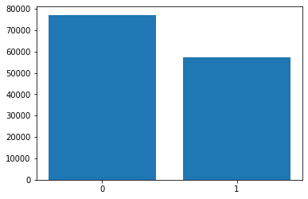

```python
#Grafico de barras variable Y
plt.bar(['0','1'], [datay[0], datay[1]])
```

- bodmas_malware_category.csv

```python
#Longitud del segundo dataset
len(datostipos)
```

```
57293
```

```python
#Tipos de malware
grouped = datostipos.groupby(datostipos.category).count().sort_values(by='sha256', ascending=False)
grouped.index
```

```
Index(['trojan', 'worm', 'backdoor', 'downloader', 'ransomware', 'dropper',
       'informationstealer', 'virus', 'pua', 'cryptominer', 'p2p-worm',
       'exploit', 'trojan-gamethief', 'rootkit'],
      dtype='object', name='category')
```

```python
#Top 5 tipos de malware
bigs = grouped.head(5)
bigs
```

| category | sha256 |
| --- | --- |
| trojan | 29972 |
| worm | 16697 |
| backdoor | 7331 |
| downloader | 1031 |
| ransomware | 821 |

```
<BarContainer object of 5 artists>
```

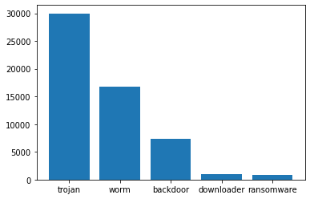

```python
#Grafico de barras de Top 5 tipos de malware
plt.bar(bigs.index, bigs.sha256)
```

### 2. Red neuronal artificial: Clasificación

En este apartado entrenaremos un modelo que intente clasificar las muestras según su tipo benigno o malicioso. Para ello crearemos una nueva variable para hacer el proceso más entendible, siguiendo las siguientes condiciones:

- Benigno: para las muestras que sean 0.
- Maligno: para las muestras que sean 1.

#### Pre-procesado

```python
#Conversión variable y
df = pd.DataFrame()
df['Y'] = datos['y']
df['Y'] = ['Benigno' if i == 0 else 'Maligno' if i == 1 else '' for i in df['Y']]
```

```python
#Normalizar los vectores de caracteristicas
ss = StandardScaler()
features = ss.fit_transform(X)
```

```python
#Binarización de variable Y
labels = pd.get_dummies(df['Y'])
```

```python
#Conversión a conjunto train y test
x = features
y = labels
x_train, x_test, y_train, y_test = train_test_split(x, y, test_size=0.2)
```

```python
#Shapes
print(x_train.shape)
print(x_test.shape)
print(y_train.shape)
print(y_test.shape)
```

```
(107548, 2332)
(26887, 2332)
(107548, 2)
(26887, 2)
```

#### Elección modelo base

Empezaremos diseñando varios modelos con diferente número de neuronas y diferente función de activación para compararlos y elegir el mejor. Para el ajuste del modelo usaremos los datos de test como conjunto de validación. Ajustando el modelo con 20 épocas y un tamaño del batch de 64.

Mostrara las gráficas de accuracy y loss. En cada gráfica se visualiza la curva de entrenamiento y la de validación.

```python
#Creación de modelos y dimensiones de entrada y salida
in_dim = 2332
out_dim = 2

model = Sequential()
model.add(Dense(2332, input_shape=(in_dim,), activation='sigmoid'))
model.add(Dense(out_dim, activation='sigmoid'))

model2 = Sequential()
model2.add(Dense(3498, input_shape=(in_dim,), activation='sigmoid'))
model2.add(Dense(out_dim, activation='sigmoid'))

model3 = Sequential()
model3.add(Dense(4664, input_shape=(in_dim,), activation='sigmoid'))
model3.add(Dense(out_dim, activation='sigmoid'))

model4 = Sequential()
model4.add(Dense(2332, input_shape=(in_dim,), activation='relu'))
model4.add(Dense(out_dim, activation='sigmoid'))

model5 = Sequential()
model5.add(Dense(3498, input_shape=(in_dim,), activation='relu'))
model5.add(Dense(out_dim, activation='sigmoid'))

model6 = Sequential()
model6.add(Dense(4664, input_shape=(in_dim,), activation='relu'))
model6.add(Dense(out_dim, activation='sigmoid'))

model7 = Sequential()
model7.add(Dense(2332, input_shape=(in_dim,), activation='tanh'))
model7.add(Dense(out_dim, activation='sigmoid'))

model8 = Sequential()
model8.add(Dense(3498, input_shape=(in_dim,), activation='tanh'))
model8.add(Dense(out_dim, activation='sigmoid'))

model9 = Sequential()
model9.add(Dense(4664, input_shape=(in_dim,), activation='tanh'))
model9.add(Dense(out_dim, activation='sigmoid'))
```

```python
#Compile
model.compile(loss='binary_crossentropy', optimizer=Adam(learning_rate=0.1), metrics=['accuracy'])
```

```python
history = model.fit(x_train, y_train, epochs=20, validation_data=(x_test, y_test), batch_size=64)
```

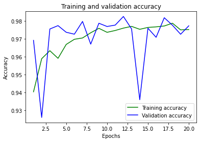

```python
#Plots
acc_train1 = history.history['accuracy']
acc_val1 = history.history['val_accuracy']
epochs = range(1,21)
plt.plot(epochs, acc_train1, 'g', label='Training accuracy')
plt.plot(epochs, acc_val1, 'b', label='Validation accuracy')
plt.title('Training and validation accuracy')
plt.xlabel('Epochs')
plt.ylabel('Accuracy')
plt.legend()
plt.show()
```

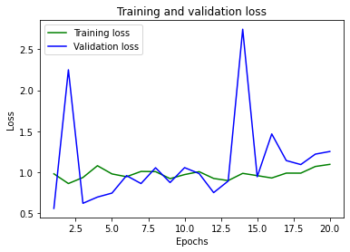

```python
loss_train1 = history.history['loss']
loss_val1 = history.history['val_loss']
epochs = range(1,21)
plt.plot(epochs, loss_train1, 'g', label='Training loss')
plt.plot(epochs, loss_val1, 'b', label='Validation loss')
plt.title('Training and validation loss')
plt.xlabel('Epochs')
plt.ylabel('Loss')
plt.legend()
plt.show()
```

```python
#Compile
model2.compile(loss='binary_crossentropy', optimizer=Adam(learning_rate=0.1), metrics=['accuracy'])
```

```python
history2 = model2.fit(x_train, y_train, epochs=20, validation_data=(x_test, y_test), batch_size=64)
```

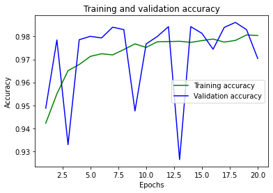

```python
#Plots
acc_train2 = history2.history['accuracy']
acc_val2 = history2.history['val_accuracy']
epochs = range(1,21)
plt.plot(epochs, acc_train2, 'g', label='Training accuracy')
plt.plot(epochs, acc_val2, 'b', label='Validation accuracy')
plt.title('Training and validation accuracy')
plt.xlabel('Epochs')
plt.ylabel('Accuracy')
plt.legend()
plt.show()
```

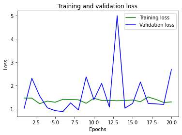

```python
loss_train2 = history2.history['loss']
loss_val2 = history2.history['val_loss']
epochs = range(1,21)
plt.plot(epochs, loss_train2, 'g', label='Training loss')
plt.plot(epochs, loss_val2, 'b', label='Validation loss')
plt.title('Training and validation loss')
plt.xlabel('Epochs')
plt.ylabel('Loss')
plt.legend()
plt.show()
```

```python
#Compile
model3.compile(loss='binary_crossentropy', optimizer=Adam(learning_rate=0.1), metrics=['accuracy'])
```

```python
history3 = model3.fit(x_train, y_train, epochs=20, validation_data=(x_test, y_test), batch_size=64)
```

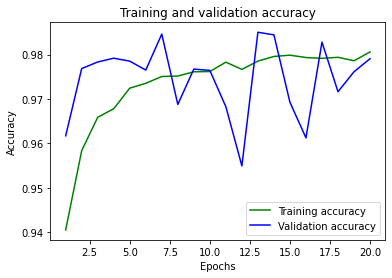

```python
#Plots
acc_train3 = history3.history['accuracy']
acc_val3 = history3.history['val_accuracy']
epochs = range(1,21)
plt.plot(epochs, acc_train3, 'g', label='Training accuracy')
plt.plot(epochs, acc_val3, 'b', label='Validation accuracy')
plt.title('Training and validation accuracy')
plt.xlabel('Epochs')
plt.ylabel('Accuracy')
plt.legend()
plt.show()
```

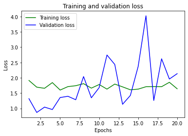

```python
loss_train3 = history3.history['loss']
loss_val3 = history3.history['val_loss']
epochs = range(1,21)
plt.plot(epochs, loss_train3, 'g', label='Training loss')
plt.plot(epochs, loss_val3, 'b', label='Validation loss')
plt.title('Training and validation loss')
plt.xlabel('Epochs')
plt.ylabel('Loss')
plt.legend()
plt.show()
```

```python
#Compile
model4.compile(loss='binary_crossentropy', optimizer=Adam(learning_rate=0.1), metrics=['accuracy'])
```

```python
history4 = model4.fit(x_train, y_train, epochs=20, validation_data=(x_test, y_test), batch_size=64)
```

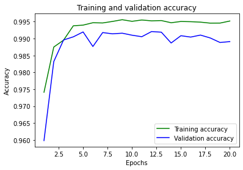

```python
#Plots
acc_train4 = history4.history['accuracy']
acc_val4 = history4.history['val_accuracy']
epochs = range(1,21)
plt.plot(epochs, acc_train4, 'g', label='Training accuracy')
plt.plot(epochs, acc_val4, 'b', label='Validation accuracy')
plt.title('Training and validation accuracy')
plt.xlabel('Epochs')
plt.ylabel('Accuracy')
plt.legend()
plt.show()
```

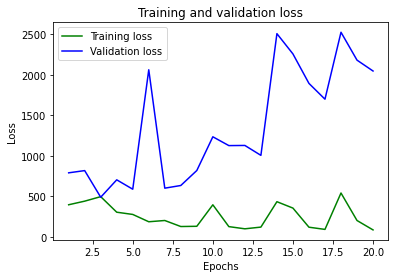

```python
loss_train4 = history4.history['loss']
loss_val4 = history4.history['val_loss']
epochs = range(1,21)
plt.plot(epochs, loss_train4, 'g', label='Training loss')
plt.plot(epochs, loss_val4, 'b', label='Validation loss')
plt.title('Training and validation loss')
plt.xlabel('Epochs')
plt.ylabel('Loss')
plt.legend()
plt.show()
```

```python
#Compile
model5.compile(loss='binary_crossentropy', optimizer=Adam(learning_rate=0.1), metrics=['accuracy'])
```

```python
history5 = model5.fit(x_train, y_train, epochs=20, validation_data=(x_test, y_test), batch_size=64)
```

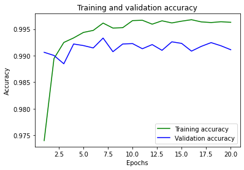

```python
#Plots
acc_train5 = history5.history['accuracy']
acc_val5 = history5.history['val_accuracy']
epochs = range(1,21)
plt.plot(epochs, acc_train5, 'g', label='Training accuracy')
plt.plot(epochs, acc_val5, 'b', label='Validation accuracy')
plt.title('Training and validation accuracy')
plt.xlabel('Epochs')
plt.ylabel('Accuracy')
plt.legend()
plt.show()
```

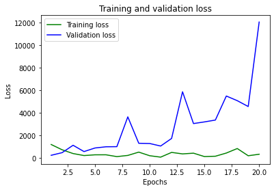

```python
loss_train5 = history5.history['loss']
loss_val5 = history5.history['val_loss']
epochs = range(1,21)
plt.plot(epochs, loss_train5, 'g', label='Training loss')
plt.plot(epochs, loss_val5, 'b', label='Validation loss')
plt.title('Training and validation loss')
plt.xlabel('Epochs')
plt.ylabel('Loss')
plt.legend()
plt.show()
```

```python
#Compile
model6.compile(loss='binary_crossentropy', optimizer=Adam(learning_rate=0.1), metrics=['accuracy'])
```

```python
history6 = model6.fit(x_train, y_train, epochs=20, validation_data=(x_test, y_test), batch_size=64)
```

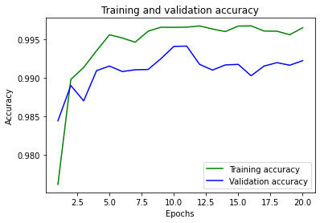

```python
#Plots
acc_train6 = history6.history['accuracy']
acc_val6 = history6.history['val_accuracy']
epochs = range(1,21)
plt.plot(epochs, acc_train6, 'g', label='Training accuracy')
plt.plot(epochs, acc_val6, 'b', label='Validation accuracy')
plt.title('Training and validation accuracy')
plt.xlabel('Epochs')
plt.ylabel('Accuracy')
plt.legend()
plt.show()
```

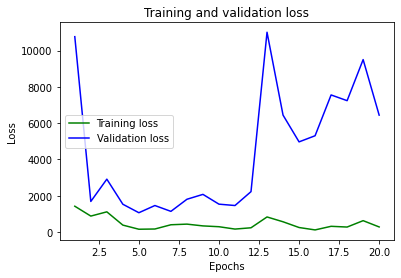

```python
loss_train6 = history6.history['loss']
loss_val6 = history6.history['val_loss']
epochs = range(1,21)
plt.plot(epochs, loss_train6, 'g', label='Training loss')
plt.plot(epochs, loss_val6, 'b', label='Validation loss')
plt.title('Training and validation loss')
plt.xlabel('Epochs')
plt.ylabel('Loss')
plt.legend()
plt.show()
```

```python
#Compile
model7.compile(loss='binary_crossentropy', optimizer=Adam(learning_rate=0.1), metrics=['accuracy'])
```

```python
history7 = model7.fit(x_train, y_train, epochs=20, validation_data=(x_test, y_test), batch_size=64)
```

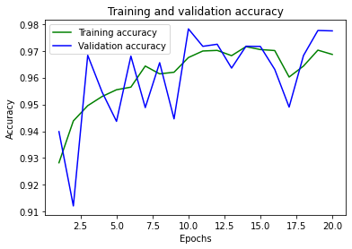

```python
#Plots
acc_train7 = history7.history['accuracy']
acc_val7 = history7.history['val_accuracy']
epochs = range(1,21)
plt.plot(epochs, acc_train7, 'g', label='Training accuracy')
plt.plot(epochs, acc_val7, 'b', label='Validation accuracy')
plt.title('Training and validation accuracy')
plt.xlabel('Epochs')
plt.ylabel('Accuracy')
plt.legend()
plt.show()
```

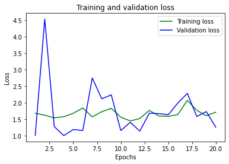

```python
loss_train7 = history7.history['loss']
loss_val7 = history7.history['val_loss']
epochs = range(1,21)
plt.plot(epochs, loss_train7, 'g', label='Training loss')
plt.plot(epochs, loss_val7, 'b', label='Validation loss')
plt.title('Training and validation loss')
plt.xlabel('Epochs')
plt.ylabel('Loss')
plt.legend()
plt.show()
```

```python
#Compile
model8.compile(loss='binary_crossentropy', optimizer=Adam(learning_rate=0.1), metrics=['accuracy'])
```

```python
history8 = model8.fit(x_train, y_train, epochs=20, validation_data=(x_test, y_test), batch_size=64)
```

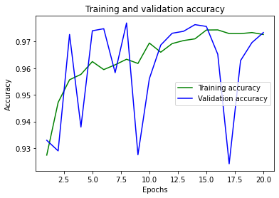

```python
#Plots
acc_train8 = history8.history['accuracy']
acc_val8 = history8.history['val_accuracy']
epochs = range(1,21)
plt.plot(epochs, acc_train8, 'g', label='Training accuracy')
plt.plot(epochs, acc_val8, 'b', label='Validation accuracy')
plt.title('Training and validation accuracy')
plt.xlabel('Epochs')
plt.ylabel('Accuracy')
plt.legend()
plt.show()
```

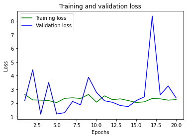

```python
loss_train8 = history8.history['loss']
loss_val8 = history8.history['val_loss']
epochs = range(1,21)
plt.plot(epochs, loss_train8, 'g', label='Training loss')
plt.plot(epochs, loss_val8, 'b', label='Validation loss')
plt.title('Training and validation loss')
plt.xlabel('Epochs')
plt.ylabel('Loss')
plt.legend()
plt.show()
```

```python
#Compile
model9.compile(loss='binary_crossentropy', optimizer=Adam(learning_rate=0.1), metrics=['accuracy'])
```

```python
history9 = model9.fit(x_train, y_train, epochs=20, validation_data=(x_test, y_test), batch_size=64)
```

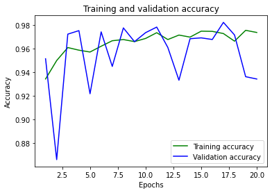

```python
#Plots
acc_train9 = history9.history['accuracy']
acc_val9 = history9.history['val_accuracy']
epochs = range(1,21)
plt.plot(epochs, acc_train9, 'g', label='Training accuracy')
plt.plot(epochs, acc_val9, 'b', label='Validation accuracy')
plt.title('Training and validation accuracy')
plt.xlabel('Epochs')
plt.ylabel('Accuracy')
plt.legend()
plt.show()
```

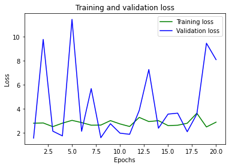

```python
loss_train9 = history9.history['loss']
loss_val9 = history9.history['val_loss']
epochs = range(1,21)
plt.plot(epochs, loss_train9, 'g', label='Training loss')
plt.plot(epochs, loss_val9, 'b', label='Validation loss')
plt.title('Training and validation loss')
plt.xlabel('Epochs')
plt.ylabel('Loss')
plt.legend()
plt.show()
```

#### Elección arquitectura

Continuaremos utilizando el modelo base anterior, para diseñar varios modelo con diferentes arquitecturas para compararlos y elegir el mejor.

Mostrara las gráficas de accuracy y loss. En cada gráfica se visualiza la curva de entrenamiento y la de validación.

```python
#Segunda creación de modelos
model = Sequential()
model.add(Dense(2332, input_shape=(in_dim,), activation='sigmoid'))
model.add(Dense(out_dim, activation='sigmoid'))

model2 = Sequential()
model2.add(Dense(2332, input_shape=(in_dim,), activation='sigmoid'))
model2.add(Dense(2332, activation='sigmoid'))
model2.add(Dense(out_dim, activation='sigmoid'))

model3 = Sequential()
model3.add(Dense(2332, input_shape=(in_dim,), activation='sigmoid'))
model3.add(Dense(1200, activation='sigmoid'))
model3.add(Dense(out_dim, activation='sigmoid'))

model4 = Sequential()
model4.add(Dense(2332, input_shape=(in_dim,), activation='sigmoid'))
model4.add(Dense(4000, activation='sigmoid'))
model4.add(Dense(out_dim, activation='sigmoid'))

model5 = Sequential()
model5.add(Dense(2332, input_shape=(in_dim,), activation='sigmoid'))
model5.add(Dense(1200, activation='sigmoid'))
model5.add(Dense(600, activation='sigmoid'))
model5.add(Dense(out_dim, activation='sigmoid'))

model6 = Sequential()
model6.add(Dense(2332, input_shape=(in_dim,), activation='sigmoid'))
model6.add(Dense(2332, activation='sigmoid'))
model6.add(Dense(1200, activation='sigmoid'))
model6.add(Dense(out_dim, activation='sigmoid'))

model7 = Sequential()
model7.add(Dense(2332, input_shape=(in_dim,), activation='sigmoid'))
model7.add(Dense(4000, activation='sigmoid'))
model7.add(Dense(2000, activation='sigmoid'))
model7.add(Dense(out_dim, activation='sigmoid'))

model8 = Sequential()
model8.add(Dense(2332, input_shape=(in_dim,), activation='sigmoid'))
model8.add(Dense(1200, activation='sigmoid'))
model8.add(Dense(400, activation='sigmoid'))
model8.add(Dense(100, activation='sigmoid'))
model8.add(Dense(out_dim, activation='sigmoid'))

model9 = Sequential()
model9.add(Dense(2332, input_shape=(in_dim,), activation='sigmoid'))
model9.add(Dense(2332, activation='sigmoid'))
model9.add(Dense(1200, activation='sigmoid'))
model9.add(Dense(300, activation='sigmoid'))
model9.add(Dense(out_dim, activation='sigmoid'))

model10 = Sequential()
model10.add(Dense(2332, input_shape=(in_dim,), activation='sigmoid'))
model10.add(Dense(4000, activation='sigmoid'))
model10.add(Dense(2000, activation='sigmoid'))
model10.add(Dense(500, activation='sigmoid'))
model10.add(Dense(out_dim, activation='sigmoid'))
```

```python
#Compile
model.compile(loss='binary_crossentropy', optimizer=Adam(learning_rate=0.1), metrics=['accuracy'])
```

```python
history = model.fit(x_train, y_train, epochs=20, validation_data=(x_test, y_test), batch_size=64)
```

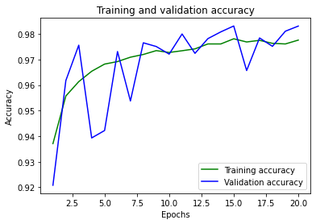

```python
#Plots
acc_train1 = history.history['accuracy']
acc_val1 = history.history['val_accuracy']
epochs = range(1,21)
plt.plot(epochs, acc_train1, 'g', label='Training accuracy')
plt.plot(epochs, acc_val1, 'b', label='Validation accuracy')
plt.title('Training and validation accuracy')
plt.xlabel('Epochs')
plt.ylabel('Accuracy')
plt.legend()
plt.show()
```

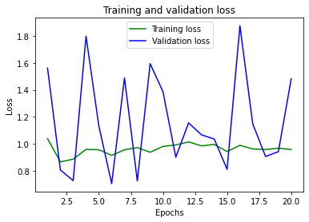

```python
loss_train1 = history.history['loss']
loss_val1 = history.history['val_loss']
epochs = range(1,21)
plt.plot(epochs, loss_train1, 'g', label='Training loss')
plt.plot(epochs, loss_val1, 'b', label='Validation loss')
plt.title('Training and validation loss')
plt.xlabel('Epochs')
plt.ylabel('Loss')
plt.legend()
plt.show()
```

```python
#Compile
model2.compile(loss='binary_crossentropy', optimizer=Adam(learning_rate=0.1), metrics=['accuracy'])
```

```python
history2 = model2.fit(x_train, y_train, epochs=20, validation_data=(x_test, y_test), batch_size=64)
```

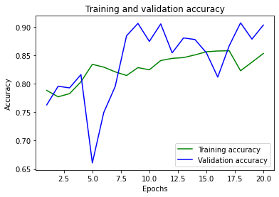

```python
#Plots
acc_train2 = history2.history['accuracy']
acc_val2 = history2.history['val_accuracy']
epochs = range(1,21)
plt.plot(epochs, acc_train2, 'g', label='Training accuracy')
plt.plot(epochs, acc_val2, 'b', label='Validation accuracy')
plt.title('Training and validation accuracy')
plt.xlabel('Epochs')
plt.ylabel('Accuracy')
plt.legend()
plt.show()
```

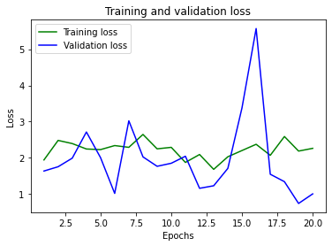

```python
loss_train2 = history2.history['loss']
loss_val2 = history2.history['val_loss']
epochs = range(1,21)
plt.plot(epochs, loss_train2, 'g', label='Training loss')
plt.plot(epochs, loss_val2, 'b', label='Validation loss')
plt.title('Training and validation loss')
plt.xlabel('Epochs')
plt.ylabel('Loss')
plt.legend()
plt.show()
```

```python
#Compile
model3.compile(loss='binary_crossentropy', optimizer=Adam(learning_rate=0.1), metrics=['accuracy'])
```

```python
history3 = model3.fit(x_train, y_train, epochs=20, validation_data=(x_test, y_test), batch_size=64)
```

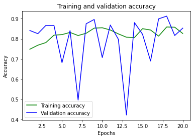

```python
#Plots
acc_train3 = history3.history['accuracy']
acc_val3 = history3.history['val_accuracy']
epochs = range(1,21)
plt.plot(epochs, acc_train3, 'g', label='Training accuracy')
plt.plot(epochs, acc_val3, 'b', label='Validation accuracy')
plt.title('Training and validation accuracy')
plt.xlabel('Epochs')
plt.ylabel('Accuracy')
plt.legend()
plt.show()
```

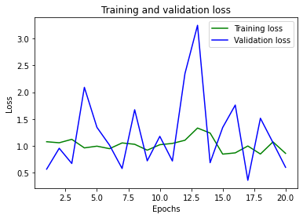

```python
loss_train3 = history3.history['loss']
loss_val3 = history3.history['val_loss']
epochs = range(1,21)
plt.plot(epochs, loss_train3, 'g', label='Training loss')
plt.plot(epochs, loss_val3, 'b', label='Validation loss')
plt.title('Training and validation loss')
plt.xlabel('Epochs')
plt.ylabel('Loss')
plt.legend()
plt.show()
```

```python
#Compile
model4.compile(loss='binary_crossentropy', optimizer=Adam(learning_rate=0.1), metrics=['accuracy'])
```

```python
history4 = model4.fit(x_train, y_train, epochs=20, validation_data=(x_test, y_test), batch_size=64)
```

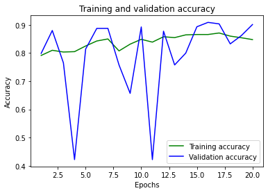

```python
#Plots
acc_train4 = history4.history['accuracy']
acc_val4 = history4.history['val_accuracy']
epochs = range(1,21)
plt.plot(epochs, acc_train4, 'g', label='Training accuracy')
plt.plot(epochs, acc_val4, 'b', label='Validation accuracy')
plt.title('Training and validation accuracy')
plt.xlabel('Epochs')
plt.ylabel('Accuracy')
plt.legend()
plt.show()
```

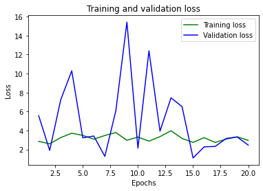

```python
loss_train4 = history4.history['loss']
loss_val4 = history4.history['val_loss']
epochs = range(1,21)
plt.plot(epochs, loss_train4, 'g', label='Training loss')
plt.plot(epochs, loss_val4, 'b', label='Validation loss')
plt.title('Training and validation loss')
plt.xlabel('Epochs')
plt.ylabel('Loss')
plt.legend()
plt.show()
```

```python
#Compile
model5.compile(loss='binary_crossentropy', optimizer=Adam(learning_rate=0.1), metrics=['accuracy'])
```

```python
history5 = model5.fit(x_train, y_train, epochs=20, validation_data=(x_test, y_test), batch_size=64)
```

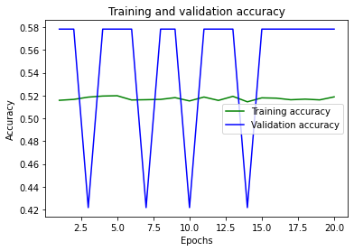

```python
#Plots
acc_train5 = history5.history['accuracy']
acc_val5 = history5.history['val_accuracy']
epochs = range(1,21)
plt.plot(epochs, acc_train5, 'g', label='Training accuracy')
plt.plot(epochs, acc_val5, 'b', label='Validation accuracy')
plt.title('Training and validation accuracy')
plt.xlabel('Epochs')
plt.ylabel('Accuracy')
plt.legend()
plt.show()
```

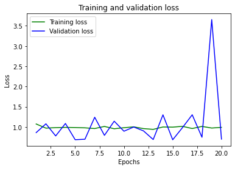

```python
loss_train5 = history5.history['loss']
loss_val5 = history5.history['val_loss']
epochs = range(1,21)
plt.plot(epochs, loss_train5, 'g', label='Training loss')
plt.plot(epochs, loss_val5, 'b', label='Validation loss')
plt.title('Training and validation loss')
plt.xlabel('Epochs')
plt.ylabel('Loss')
plt.legend()
plt.show()
```

```python
#Compile
model6.compile(loss='binary_crossentropy', optimizer=Adam(learning_rate=0.1), metrics=['accuracy'])
```

```python
history6 = model6.fit(x_train, y_train, epochs=20, validation_data=(x_test, y_test), batch_size=64)
```

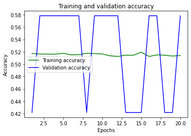

```python
#Plots
acc_train6 = history6.history['accuracy']
acc_val6 = history6.history['val_accuracy']
epochs = range(1,21)
plt.plot(epochs, acc_train6, 'g', label='Training accuracy')
plt.plot(epochs, acc_val6, 'b', label='Validation accuracy')
plt.title('Training and validation accuracy')
plt.xlabel('Epochs')
plt.ylabel('Accuracy')
plt.legend()
plt.show()
```

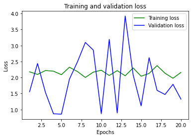

```python
loss_train6 = history6.history['loss']
loss_val6 = history6.history['val_loss']
epochs = range(1,21)
plt.plot(epochs, loss_train6, 'g', label='Training loss')
plt.plot(epochs, loss_val6, 'b', label='Validation loss')
plt.title('Training and validation loss')
plt.xlabel('Epochs')
plt.ylabel('Loss')
plt.legend()
plt.show()
```

```python
#Compile
model7.compile(loss='binary_crossentropy', optimizer=Adam(learning_rate=0.1), metrics=['accuracy'])
```

```python
history7 = model7.fit(x_train, y_train, epochs=20, validation_data=(x_test, y_test), batch_size=64)
```

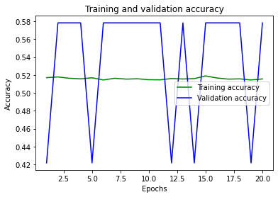

```python
#Plots
acc_train7 = history7.history['accuracy']
acc_val7 = history7.history['val_accuracy']
epochs = range(1,21)
plt.plot(epochs, acc_train7, 'g', label='Training accuracy')
plt.plot(epochs, acc_val7, 'b', label='Validation accuracy')
plt.title('Training and validation accuracy')
plt.xlabel('Epochs')
plt.ylabel('Accuracy')
plt.legend()
plt.show()
```

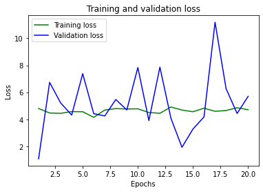

```python
loss_train7 = history7.history['loss']
loss_val7 = history7.history['val_loss']
epochs = range(1,21)
plt.plot(epochs, loss_train7, 'g', label='Training loss')
plt.plot(epochs, loss_val7, 'b', label='Validation loss')
plt.title('Training and validation loss')
plt.xlabel('Epochs')
plt.ylabel('Loss')
plt.legend()
plt.show()
```

```python
#Compile
model8.compile(loss='binary_crossentropy', optimizer=Adam(learning_rate=0.1), metrics=['accuracy'])
```

```python
history8 = model8.fit(x_train, y_train, epochs=20, validation_data=(x_test, y_test), batch_size=64)
```

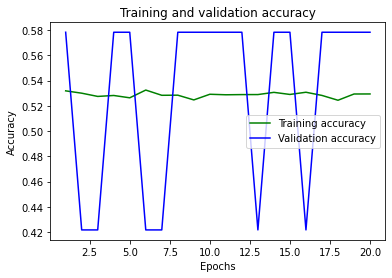

```python
#Plots
acc_train8 = history8.history['accuracy']
acc_val8 = history8.history['val_accuracy']
epochs = range(1,21)
plt.plot(epochs, acc_train8, 'g', label='Training accuracy')
plt.plot(epochs, acc_val8, 'b', label='Validation accuracy')
plt.title('Training and validation accuracy')
plt.xlabel('Epochs')
plt.ylabel('Accuracy')
plt.legend()
plt.show()
```

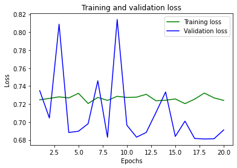

```python
loss_train8 = history8.history['loss']
loss_val8 = history8.history['val_loss']
epochs = range(1,21)
plt.plot(epochs, loss_train8, 'g', label='Training loss')
plt.plot(epochs, loss_val8, 'b', label='Validation loss')
plt.title('Training and validation loss')
plt.xlabel('Epochs')
plt.ylabel('Loss')
plt.legend()
plt.show()
```

```python
#Compile
model9.compile(loss='binary_crossentropy', optimizer=Adam(learning_rate=0.1), metrics=['accuracy'])
```

```python
history9 = model9.fit(x_train, y_train, epochs=20, validation_data=(x_test, y_test), batch_size=64)
```

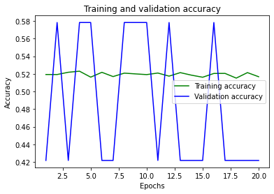

```python
#Plots
acc_train9 = history9.history['accuracy']
acc_val9 = history9.history['val_accuracy']
epochs = range(1,21)
plt.plot(epochs, acc_train9, 'g', label='Training accuracy')
plt.plot(epochs, acc_val9, 'b', label='Validation accuracy')
plt.title('Training and validation accuracy')
plt.xlabel('Epochs')
plt.ylabel('Accuracy')
plt.legend()
plt.show()
```

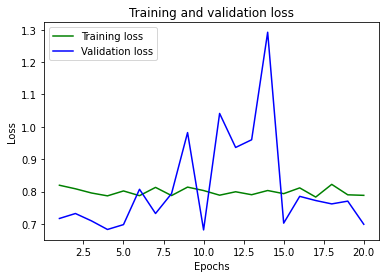

```python
loss_train9 = history9.history['loss']
loss_val9 = history9.history['val_loss']
epochs = range(1,21)
plt.plot(epochs, loss_train9, 'g', label='Training loss')
plt.plot(epochs, loss_val9, 'b', label='Validation loss')
plt.title('Training and validation loss')
plt.xlabel('Epochs')
plt.ylabel('Loss')
plt.legend()
plt.show()
```

```python
#Compile
model10.compile(loss='binary_crossentropy', optimizer=Adam(learning_rate=0.1), metrics=['accuracy'])
```

```python
history10 = model10.fit(x_train, y_train, epochs=20, validation_data=(x_test, y_test), batch_size=64)
```

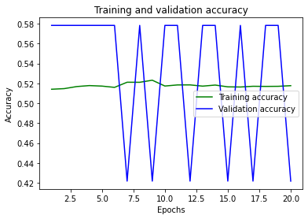

```python
#Plots
acc_train10 = history10.history['accuracy']
acc_val10 = history10.history['val_accuracy']
epochs = range(1,21)
plt.plot(epochs, acc_train10, 'g', label='Training accuracy')
plt.plot(epochs, acc_val10, 'b', label='Validation accuracy')
plt.title('Training and validation accuracy')
plt.xlabel('Epochs')
plt.ylabel('Accuracy')
plt.legend()
plt.show()
```

[figure not shown]

```python
loss_train10 = history10.history['loss']
loss_val10 = history10.history['val_loss']
epochs = range(1,21)
plt.plot(epochs, loss_train9, 'g', label='Training loss')
plt.plot(epochs, loss_val9, 'b', label='Validation loss')
plt.title('Training and validation loss')
plt.xlabel('Epochs')
plt.ylabel('Loss')
plt.legend()
plt.show()
```

#### Influencia velocidad aprendizaje y optimizador

Una vez tenemos el modelo base, analizaremos la influencia que pueden tener la velocidad de aprendizaje y el tipo de optimizador en la mejora del rendimiento.

```python
#Compilación de modelos cambiando Optimizadores y velocidad de aprendizaje
model.compile(loss='binary_crossentropy', optimizer=Adam(learning_rate=0.001), metrics=['accuracy'])
start1 = timeit.default_timer()
history1 = model.fit(x_train, y_train, epochs=20, validation_data=(x_test, y_test), batch_size=64, verbose=0)
end1 = timeit.default_timer()
acc1 = history1.history['accuracy']
acc1 = acc1[19]
time1 = end1-start1
model.compile(loss='binary_crossentropy', optimizer=Adam(learning_rate=0.01), metrics=['accuracy'])
start2 = timeit.default_timer()
history2 = model.fit(x_train, y_train, epochs=20, validation_data=(x_test, y_test), batch_size=64, verbose=0)
end2 = timeit.default_timer()
time2 = end2-start2
acc2 = history2.history['accuracy']
acc2 = acc2[19]
model.compile(loss='binary_crossentropy', optimizer=Adam(learning_rate=0.05), metrics=['accuracy'])
start3 = timeit.default_timer()
history3 = model.fit(x_train, y_train, epochs=20, validation_data=(x_test, y_test), batch_size=64, verbose=0)
end3 = timeit.default_timer()
time3 = end3-start3
acc3 = history3.history['accuracy']
acc3 = acc3[19]
model.compile(loss='binary_crossentropy', optimizer=Adam(learning_rate=0.1), metrics=['accuracy'])
start4 = timeit.default_timer()
history4 = model.fit(x_train, y_train, epochs=20, validation_data=(x_test, y_test), batch_size=64, verbose=0)
end4 = timeit.default_timer()
time4 = end4-start4
acc4 = history4.history['accuracy']
acc4 = acc4[19]
```

```python
model.compile(loss='binary_crossentropy', optimizer=SGD(learning_rate=0.001), metrics=['accuracy'])
start5 = timeit.default_timer()
history5 = model.fit(x_train, y_train, epochs=20, validation_data=(x_test, y_test), batch_size=64, verbose=0)
end5 = timeit.default_timer()
time5 = end5-start5
acc5 = history5.history['accuracy']
acc5 = acc5[19]
model.compile(loss='binary_crossentropy', optimizer=SGD(learning_rate=0.01), metrics=['accuracy'])
start6 = timeit.default_timer()
history6 = model.fit(x_train, y_train, epochs=20, validation_data=(x_test, y_test), batch_size=64, verbose=0)
end6 = timeit.default_timer()
time6 = end6-start6
acc6 = history6.history['accuracy']
acc6 = acc6[19]
model.compile(loss='binary_crossentropy', optimizer=SGD(learning_rate=0.05), metrics=['accuracy'])
start7 = timeit.default_timer()
history7 = model.fit(x_train, y_train, epochs=20, validation_data=(x_test, y_test), batch_size=64, verbose=0)
end7 = timeit.default_timer()
time7 = end7-start7
acc7 = history7.history['accuracy']
acc7 = acc7[19]
model.compile(loss='binary_crossentropy', optimizer=SGD(learning_rate=0.1), metrics=['accuracy'])
start8 = timeit.default_timer()
history8 = model.fit(x_train, y_train, epochs=20, validation_data=(x_test, y_test), batch_size=64, verbose=0)
end8 = timeit.default_timer()
time8 = end8-start8
acc8 = history8.history['accuracy']
acc8 = acc8[19]
```

```python
model.compile(loss='binary_crossentropy', optimizer=Adadelta(learning_rate=0.001), metrics=['accuracy'])
start9 = timeit.default_timer()
history9 = model.fit(x_train, y_train, epochs=20, validation_data=(x_test, y_test), batch_size=64, verbose=0)
end9 = timeit.default_timer()
time9 = end9-start9
acc9 = history9.history['accuracy']
acc9 = acc9[19]
model.compile(loss='binary_crossentropy', optimizer=Adadelta(learning_rate=0.01), metrics=['accuracy'])
start10 = timeit.default_timer()
history10 = model.fit(x_train, y_train, epochs=20, validation_data=(x_test, y_test), batch_size=64, verbose=0)
end10 = timeit.default_timer()
time10 = end10-start10
acc10 = history10.history['accuracy']
acc10 = acc10[19]
model.compile(loss='binary_crossentropy', optimizer=Adadelta(learning_rate=0.05), metrics=['accuracy'])
start11 = timeit.default_timer()
history11 = model.fit(x_train, y_train, epochs=20, validation_data=(x_test, y_test), batch_size=64, verbose=0)
end11 = timeit.default_timer()
time11 = end11-start11
acc11 = history11.history['accuracy']
acc11 = acc11[19]
model.compile(loss='binary_crossentropy', optimizer=Adadelta(learning_rate=0.1), metrics=['accuracy'])
start12 = timeit.default_timer()
history12 = model.fit(x_train, y_train, epochs=20, validation_data=(x_test, y_test), batch_size=64, verbose=0)
end12 = timeit.default_timer()
time12 = end12-start12
acc12 = history12.history['accuracy']
acc12 = acc12[19]
```

```python
model.compile(loss='binary_crossentropy', optimizer=Adagrad(learning_rate=0.001), metrics=['accuracy'])
start13 = timeit.default_timer()
history13 = model.fit(x_train, y_train, epochs=20, validation_data=(x_test, y_test), batch_size=64, verbose=0)
end13 = timeit.default_timer()
time13 = end13-start13
acc13 = history13.history['accuracy']
acc13 = acc13[19]
model.compile(loss='binary_crossentropy', optimizer=Adagrad(learning_rate=0.01), metrics=['accuracy'])
start14 = timeit.default_timer()
history14 = model.fit(x_train, y_train, epochs=20, validation_data=(x_test, y_test), batch_size=64, verbose=0)
end14 = timeit.default_timer()
time14 = end14-start14
acc14 = history14.history['accuracy']
acc14 = acc14[19]
model.compile(loss='binary_crossentropy', optimizer=Adagrad(learning_rate=0.05), metrics=['accuracy'])
start15 = timeit.default_timer()
history15 = model.fit(x_train, y_train, epochs=20, validation_data=(x_test, y_test), batch_size=64, verbose=0)
end15 = timeit.default_timer()
time15 = end15-start15
acc15 = history15.history['accuracy']
acc15 = acc15[19]
model.compile(loss='binary_crossentropy', optimizer=Adagrad(learning_rate=0.1), metrics=['accuracy'])
start16 = timeit.default_timer()
history16 = model.fit(x_train, y_train, epochs=20, validation_data=(x_test, y_test), batch_size=64, verbose=0)
end16 = timeit.default_timer()
time16 = end16-start16
acc16 = history16.history['accuracy']
acc16 = acc16[19]
```

```python
#Creación variables por optimizador de accuracy y tiempo
Opt = ['Adam', 'SGD', 'Adadelta', 'Adagrad' ]
accAdam = [acc1, acc2, acc3, acc4]
timAdam = [time1, time2, time3, time4]
accSGD = [acc5, acc6, acc7, acc8]
timSGD = [time5, time6, time7, time8]
accAdad = [acc9, acc10, acc11, acc12]
timAdad = [time9, time10, time11, time12]
accAdag = [acc13, acc14, acc15, acc16]
timAdag = [time13, time14, time15, time16]
```

```python
#Creación de tabla de accuracy
tableAcc = pd.DataFrame(list(zip(Opt, accAdam, accSGD, accAdad, accAdag,)), columns = ['Optimizer', '0.001', '0.01', '0.05', '0.1'])
tableAcc
```

|  | Optimizer | 0.001 | 0.01 | 0.05 | 0.1 |
| --- | --- | --- | --- | --- | --- |
| 0 | Adam | 0.994040 | 0.990655 | 0.992450 | 0.992775 |
| 1 | SGD | 0.995072 | 0.991492 | 0.992673 | 0.992868 |
| 2 | Adadelta | 0.988805 | 0.991976 | 0.992757 | 0.992943 |
| 3 | Adagrad | 0.981748 | 0.992403 | 0.992701 | 0.993194 |

```python
#Creación de tabla de tiempos
tableTim = pd.DataFrame(list(zip(Opt, timAdam, timSGD, timAdad, timAdag,)), columns = ['Optimizer', '0.001', '0.01', '0.05', '0.1'])
tableTim
```

|  | Optimizer | 0.001 | 0.01 | 0.05 | 0.1 |
| --- | --- | --- | --- | --- | --- |
| 0 | Adam | 84.358841 | 78.801520 | 91.206845 | 82.429691 |
| 1 | SGD | 85.116376 | 78.446127 | 90.518035 | 83.588952 |
| 2 | Adadelta | 83.904615 | 79.436879 | 89.998876 | 83.363145 |
| 3 | Adagrad | 83.613754 | 77.984087 | 89.625066 | 82.877016 |

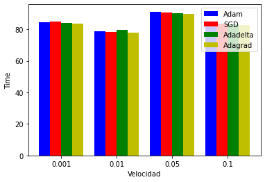

```python
#Creación variables por velocidad de aprendizaje de tiempo y plot
x = np.arange(4)
Vel1 = [time1, time5, time9, time13]
Vel2 = [time2, time6, time10, time14]
Vel3 = [time3, time7, time11, time15]
Vel4 = [time4, time8, time12, time16]
width = 0.2
plt.bar(x-0.3, Vel1, width, color='b')
plt.bar(x-0.1, Vel2, width, color='r')
plt.bar(x+0.1, Vel3, width, color='g')
plt.bar(x+0.3, Vel4, width, color='y')
plt.xticks(x, ['0.001', '0.01', '0.05', '0.1'])
plt.xlabel("Velocidad")
plt.ylabel("Time")
plt.legend(["Adam","SGD","Adadelta", "Adagrad"])
```

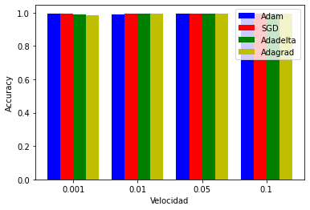

```python
#Creación variables por velocidad de aprendizaje de accuracy y plot
x = np.arange(4)
Vel1 = [acc1, acc5, acc9, acc13]
Vel2 = [acc2, acc6, acc10, acc14]
Vel3 = [acc3, acc7, acc11, acc15]
Vel4 = [acc4, acc8, acc12, acc16]
width = 0.2
plt.bar(x-0.3, Vel1, width, color='b')
plt.bar(x-0.1, Vel2, width, color='r')
plt.bar(x+0.1, Vel3, width, color='g')
plt.bar(x+0.3, Vel4, width, color='y')
plt.xticks(x, ['0.001', '0.01', '0.05', '0.1'])
plt.xlabel("Velocidad")
plt.ylabel("Accuracy")
plt.legend(["Adam","SGD","Adadelta","Adagrad"])
```